# Assignment 2, Task 1

Alessandra Puig-Santana

2023-02-13

# Introduction

In this task, we created and compared two different binary logistic regression models for predicting palmetto species in south-central Florida using a long-term dataset of the two dominant palmetto species, *Serenoa repens* and *Sabel etonia*, from the Archbold Biological Station collected between 1981-2017.

This long term data set has many species found in Florida, so we first extra the two palmetto species of interest. Then, we explore the variables within the data set, such as plant height, number of new green leaves, and canopy length and width through visualizations to better understand the relationships between species and predictor variable. Lastly, we create our models and test them using three metrics, AIC, BIC, and cross validation to determine the best suited model. ***

```r
knitr::opts_chunk$set(echo = TRUE, message = FALSE, warning = FALSE)

# Set up chunk

library(tidyverse)
library(here)
library(kableExtra)
library(AICcmodavg)
library(GGally)
library(tidymodels)
library(broom)
library(patchwork)

## Read in data
palmetto <- read_csv(here('palmetto.csv'))
```

### Data exploration

Explore differences in height, canopy length, canopy width, and green leaves for the two species-*Serenoa repens* and *Sabel etonia*.

#### Data Manipulation

```r
# Species_id 1 - Serenoa repens
# Species_id 2 - Sabal etonia

palmetto_sub <- palmetto %>%
  select(species, height:green_lvs) %>%
  mutate(species = case_when(species == "1" ~ "Serenoa repens",
                   species == "2" ~ "Sabal etonia")) %>%
  drop_na()

palmetto_sub$species <- factor(palmetto_sub$species)

class(palmetto_sub$species) # check to make sure it worked
```

```
## [1] "factor"
```

```r
levels(palmetto_sub$species) #see which one is 0 and which is 1
```

```
## [1] "Sabal etonia"   "Serenoa repens"
```

```r
# visualize using ggpairs
# ggpairs(data = palmetto_sub, aes(color = species))
```

### Data visualizations

#### Plot set 1 - Height (cm) vs Canopy length (cm)

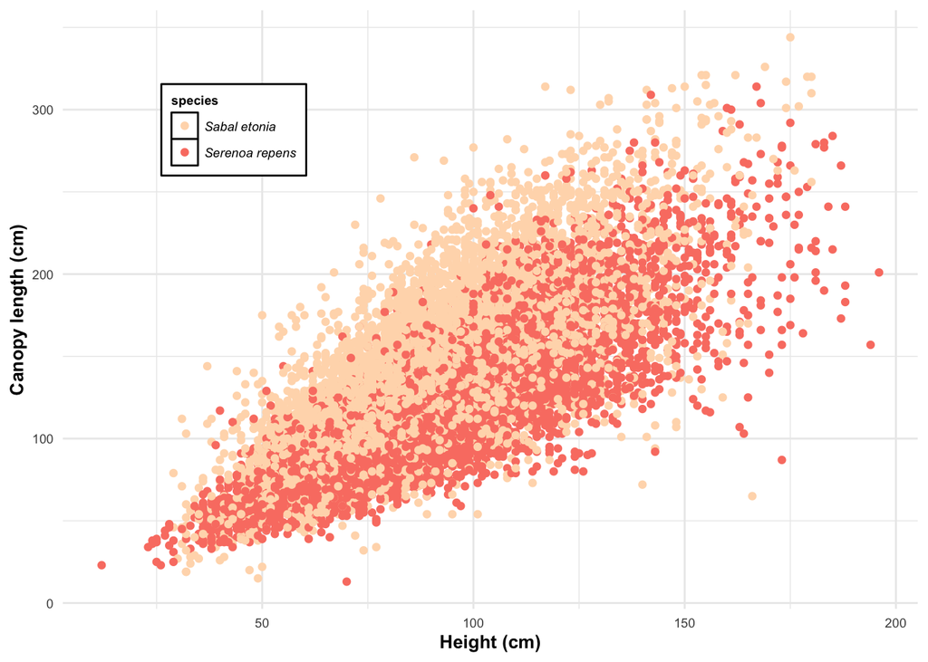

```r
p1 <- ggplot(data = palmetto_sub,
             aes(x = height,
                 y = length)) +
  geom_point(aes(color = species)) +
  labs(x = 'Height (cm)',
       y = 'Canopy length (cm)') +
  scale_color_manual(values = c('peachpuff', 'salmon')) +
  theme_minimal() +
  theme(legend.position = c(0.20, 0.8), # this customizes the legend - code lines 76-83
    legend.title = element_text(face = 'bold',
                                size = 7),
    legend.text = element_text(face = 'italic',
                               size = 7),
    legend.background = element_rect(fill = 'white'),
    legend.key = element_rect(fill = 'white'),
    legend.key.size = unit(1, 'line'),
    axis.text.x = element_text(size = 7), # customizing the x and y axes - code lines 84-87
    axis.text.y = element_text(size = 7),
    axis.title.x = element_text(size = 10, face = 'bold'),
    axis.title.y = element_text(size = 10, face = 'bold'))

p1 # calling out the first graph
```

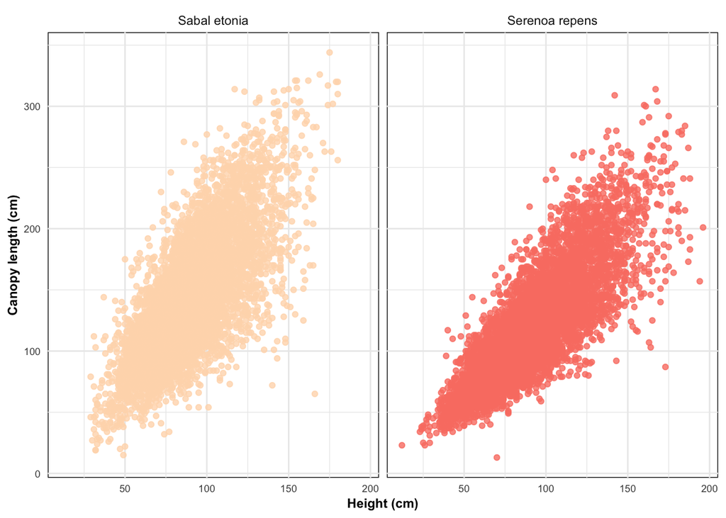

```r
p2 <- ggplot(data = palmetto_sub, aes(x = height,
                                      y = length)) +
  geom_point(aes(color = species), alpha = 0.8, show.legend = FALSE) + # not showing legend because combining graphs
  labs(x = 'Height (cm)',
       y = 'Canopy length (cm)') +
  facet_wrap(~species) + # separating them by species
  scale_color_manual(values = c('peachpuff', 'salmon'))+
  theme_minimal()+
  theme(axis.text.x = element_text(size = 7),
    axis.text.y = element_text(size = 7),
    axis.title.x = element_text(size = 9, face = 'bold'),
    axis.title.y = element_text(size = 9, face = 'bold'),
    panel.background = element_rect(fill = 'white')) # graph background color

p2
```

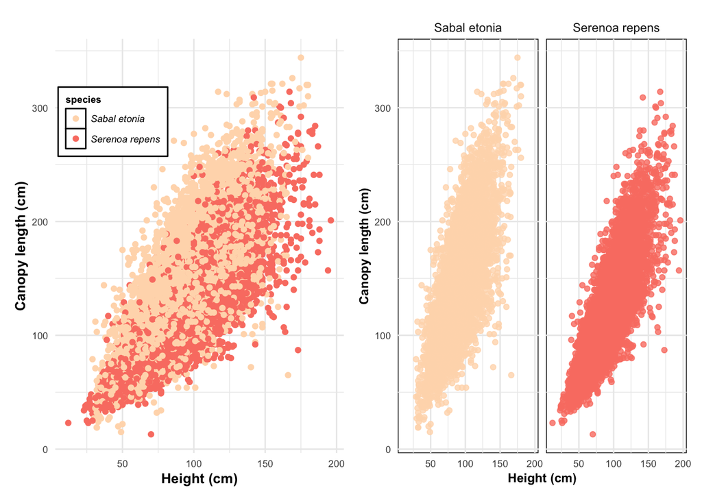

```r
# Combining both graphs using patchwork
p1 + p2
```

**Figure 1:** Height (cm) and canopy length (cm) of Palmetto species, *S. etonia* and *S. repens*, in beige and salmon, respectively. The left figure directly compares observations for both species, while the right figure separates observations to better visualize the spread of each species.

#### Plot set 2 - Height (cm) vs Canopy width (cm)

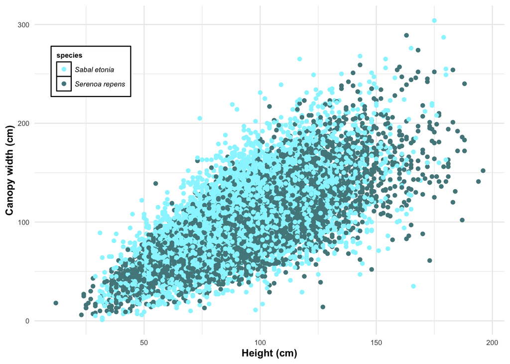

```r
p3 <- ggplot(data = palmetto_sub,
             aes(x = height,
                 y = width)) +
  geom_point(aes(color = species)) +
  labs(x = 'Height (cm)',
       y = 'Canopy width (cm)') +
  scale_color_manual(values = c('cadetblue1', 'cadetblue4')) +
  theme_minimal() +
  theme(legend.position = c(0.12, 0.8),  #customize legend elements - code lines 122-127
    legend.title = element_text(face = 'bold', size = 7),
    legend.text = element_text(face = 'italic', size = 7),
    legend.background = element_rect(fill = 'white'),
    legend.key = element_rect(fill = 'white'),
    legend.key.size = unit(1, 'line'),
    axis.text.x = element_text(size = 7), #customize axis elements - code lines 128-131
    axis.text.y = element_text(size = 7),
    axis.title.x = element_text(size = 10, face = 'bold'),
    axis.title.y = element_text(size = 10, face = 'bold'))

p3
```

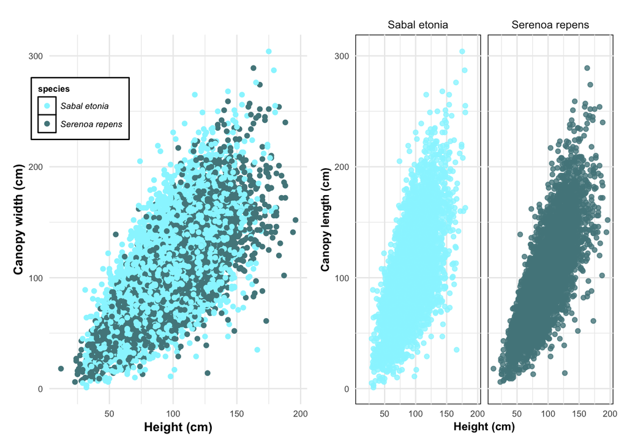

```r
p4 <- ggplot(data = palmetto_sub, aes(x = height, y = width)) +
  geom_point(aes(color = species), alpha = 0.8,
             show.legend = FALSE) + # not showing legend because combing both graphs
  labs(x = 'Height (cm)',
       y = 'Canopy length (cm)') +
  facet_wrap(~species) + # separating by species
  scale_color_manual(values = c('cadetblue1', 'cadetblue4'))+
  theme_minimal()+
  theme(axis.text.x = element_text(size = 7), # customize axis elements - code lines 143-146
    axis.text.y = element_text(size = 7),
    axis.title.x = element_text(size = 9, face = 'bold'),
    axis.title.y = element_text(size = 9, face = 'bold'),
    panel.background = element_rect(fill = 'white'))

# Combining graphs using patchwork
p3 + p4
```

**Figure 2:** Height (cm) and canopy width (cm) of Palmetto species, *S. etonia* and *S. repens*, in light blue and dark blue, respectively. The left figure directly compares observations for both species, while the right figure separates observations to better visualize the spread of each species.

#### Plot 4 - Green leaves count vs Count per species

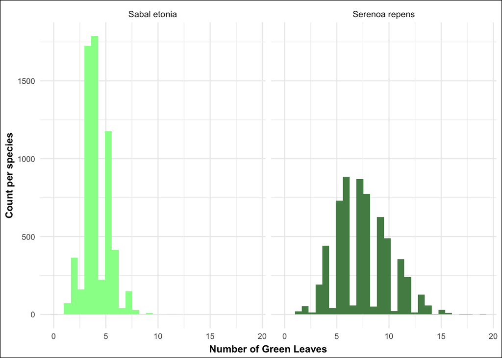

```r
p5<- ggplot(data = palmetto_sub, aes(x = green_lvs,
                                      fill = species)) +
  geom_histogram() +
  facet_wrap(~species) + #separating by species
  theme_minimal() +
  labs(x = "Number of Green Leaves",
        y = "Count per species") +
  theme(plot.title = element_text(hjust = 0.5, face = "bold", size = 12), #customizing graph layout - code lines 164-168
        plot.subtitle = element_text(hjust = 0.5, face = "bold", size = 11),
        axis.title.x = element_text(vjust = 0.2, face = "bold", size = 10),
        axis.title.y = element_text(face = "bold", size = 10),
        axis.text = element_text(size = 8),
        plot.background = element_rect(fill = "white"), #background color
        legend.position = "none") + # no legend needed
  scale_fill_manual(values = c("palegreen", "palegreen4"))

p5 #calling out graph
```

**Figure 3:** Number of green leaves found per Palmetto species, *S. etonia* and *S. repens*, in light green and dark green, respectively.

### Model creation

#### Binary Logistic Regression (BLR)

```r
# Model 1 will represent the log odds of plant type using plant height, canopy length, canopy width and green leaves as predictor variable

# Formula 1
f1 = species ~ height + length + width + green_lvs

# BLR of f1
blr1 <- glm(formula = f1,
            data = palmetto_sub,
            family = "binomial")

# Model 2 will represent log odds of plant type using plant height, canopy width and green leaves (i.e., drop canopy length for this model)

# Formula 2
f2 = species ~ height + width + green_lvs

# BLR of f2
blr2 <- glm(formula = f2,
            data = palmetto_sub,
            family = "binomial")
```

```r
# Make it tidy
tidy_blr1 <- tidy(blr1)
tidy_blr2 <- tidy(blr2)

# Tables with log odds for BLR 1 and 2
tidy_blr1 %>%
  kable(caption = "Table 1. Model 1 - Binary Logistic Regression results",
        col.names = c("Variable", "Coefficient", "Standard error", "Statistic", "p-value")) %>%
  kable_styling(full_width = FALSE,
                bootstrap_options = "hover",
                position = "center")
```

Table 1. Model 1 - Binary Logistic Regression results

| Variable | Coefficient | Standard error | Statistic | p-value |
| --- | --- | --- | --- | --- |
| (Intercept) | -3.2266851 | 0.1420708 | -22.71180 | 0 |
| height | 0.0292173 | 0.0023061 | 12.66984 | 0 |
| length | -0.0458233 | 0.0018661 | -24.55600 | 0 |
| width | -0.0394434 | 0.0021000 | -18.78227 | 0 |
| green_lvs | 1.9084747 | 0.0388634 | 49.10728 | 0 |

```r
tidy_blr2 %>%
  kable(caption = "Table 2. Model 2 - Binary Logistic Regression results",
        col.names = c("Variable", "Coefficient", "Standard error", "Statistic", "p-value")) %>%
  kable_styling(full_width = FALSE,
                bootstrap_options = "hover",
                position = "center")
```

Table 2. Model 2 - Binary Logistic Regression results

| Variable | Coefficient | Standard error | Statistic | p-value |
| --- | --- | --- | --- | --- |
| (Intercept) | -3.7677215 | 0.1353136 | -27.844371 | 0.0000000 |
| height | 0.0029504 | 0.0018811 | 1.568426 | 0.1167816 |
| width | -0.0690186 | 0.0017852 | -38.660633 | 0.0000000 |
| green_lvs | 1.8848147 | 0.0361268 | 52.172204 | 0.0000000 |

### Model testing using AIC, BIC, and cross fold validation

```r
# AIC
## showing results on a table
aictab(list(blr1, blr2)) %>%
    kable(col.names = c("Model", "Parameters", "AIC", "Delta AIC", "Model Likelihood", "AIC Weight", "Log Likelihood", "Cumulative Weight"),
        caption = "**Table 3.** AIC Results") %>%
    kable_styling(full_width = FALSE,
                bootstrap_options = "hover",
                position = "center")
```

**Table 3.** AIC Results

| Model | Parameters | AIC | Delta AIC | Model Likelihood | AIC Weight | Log Likelihood | Cumulative Weight |
| --- | --- | --- | --- | --- | --- | --- | --- |
| Mod1 | 5 | 5194.567 | 0.0000 | 1 | 1 | -2592.281 | 1 |
| Mod2 | 4 | 5987.475 | 792.9086 | 0 | 0 | -2989.736 | 1 |

```r
# BIC
## showing results on a table
bictab(list(blr1, blr2)) %>%
    kable(col.names = c("Model", "Parameters", "BIC", "Delta BIC", "Model Likelihood", "BIC Weight", "Log Likelihood", "Cumulative Weight"),
        caption = "Table 4. BIC Results") %>%
      kable_styling(full_width = FALSE,
                bootstrap_options = "hover",
                position = "center")
```

Table 4. BIC Results

| Model | Parameters | BIC | Delta BIC | Model Likelihood | BIC Weight | Log Likelihood | Cumulative Weight |
| --- | --- | --- | --- | --- | --- | --- | --- |
| Mod1 | 5 | 5231.635 | 0.0000 | 1 | 1 | -2592.281 | 1 |
| Mod2 | 4 | 6017.131 | 785.4956 | 0 | 0 | -2989.736 | 1 |

```r
# Cross fold validation

## set seed for reproducibility
set.seed(123)

## set number of folds to 10 and repeat it 5 times
tidy_folds <- vfold_cv(palmetto_sub, v = 10, repeats = 10)

## Create general BLR model
blr_model <- logistic_reg() %>%
  set_engine('glm')

# Workflow that bundles the logistic model and formula 1
blr_tidy_f1 <- workflow() %>%
  add_model(blr_model) %>%
  add_formula(f1)

blr_tidy_cv_f1 <- blr_tidy_f1 %>%
  fit_resamples(tidy_folds)

# Use functions from the tune package to extract metrics
metrics1<- collect_metrics(blr_tidy_cv_f1)

# Making a table displaying model 1 metrics from CV
metrics <- metrics1 %>%
  kable(col.names = c("Metric",
                      "Estimator",
                      "Mean",
                      "n",
                      "Standard Error",
                      "Configuration"),
        caption = "**Table 5.** Model 1 - Cross Validation Metrics") %>%
      kable_styling(full_width = FALSE,
                bootstrap_options = "hover",
                position = "center")

metrics #calling out table
```

**Table 5.** Model 1 - Cross Validation Metrics

| Metric | Estimator | Mean | n | Standard Error | Configuration |
| --- | --- | --- | --- | --- | --- |
| accuracy | binary | 0.9168175 | 100 | 0.0007854 | Preprocessor1_Model1 |
| roc_auc | binary | 0.9724926 | 100 | 0.0003756 | Preprocessor1_Model1 |

```r
# Model 2
blr_tidy_f2 <- workflow() %>%
  add_model(blr_model) %>%
  add_formula(f2)

blr_tidy_cv_f2 <- blr_tidy_f2 %>%
  fit_resamples(tidy_folds)

# Use functions from the tune package to extract metrics
metrics2 <- collect_metrics(blr_tidy_cv_f2)

# Making a table displaying model 2 metrics from CV
metrics_2 <- metrics2 %>%
  kable(col.names = c("Metric", "Estimator", "Mean", "n", "Standard Error", "Configuration"),
        caption = "Table 6. Model 2 - Cross Validation Metrics") %>%
      kable_styling(full_width = FALSE,
                bootstrap_options = "hover",
                position = "center")

metrics_2 #calling out table
```

Table 6. Model 2 - Cross Validation Metrics

| Metric | Estimator | Mean | n | Standard Error | Configuration |
| --- | --- | --- | --- | --- | --- |
| accuracy | binary | 0.8987528 | 100 | 0.0009137 | Preprocessor1_Model1 |
| roc_auc | binary | 0.9634662 | 100 | 0.0004368 | Preprocessor1_Model1 |

Based on the AIC, BIC, and 10-fold cross validation values, Model 1 performs better. The AIC and BIC for model 1 were lower and the mean accuracy metric was 0.917 compared to 0.899 for model 2.

```r
# Using entire dataset to identify the coefficients for the final predictive model based on model 1 because it had the lowest AIC and BIC values

f1_blr_fit <- blr_model %>%
  fit(f1,
      data = palmetto_sub)

coefficient_df <- f1_blr_fit %>%
  tidy() %>%
  kable(col.names = c("Term", "Estimate","Standard Error", "Statistic", "P-Value"),
        caption = "Table 7. Coefficients for Final Predictive Model") %>%
      kable_styling(full_width = FALSE,
                bootstrap_options = "hover",
                position = "center")

coefficient_df # calling table out
```

Table 7. Coefficients for Final Predictive Model

| Term | Estimate | Standard Error | Statistic | P-Value |
| --- | --- | --- | --- | --- |
| (Intercept) | -3.2266851 | 0.1420708 | -22.71180 | 0 |
| height | 0.0292173 | 0.0023061 | 12.66984 | 0 |
| length | -0.0458233 | 0.0018661 | -24.55600 | 0 |
| width | -0.0394434 | 0.0021000 | -18.78227 | 0 |
| green_lvs | 1.9084747 | 0.0388634 | 49.10728 | 0 |

```r
# Finding probabilities associated with a palmetto being S etonia or S repens based on model 1 because it is easier to interpret

blr1_fitted <- blr1 %>%
  broom::augment(type.predict = "response") %>%

# Adding columns to see if the model correctly guessed the species
  mutate(species_predicted= case_when(.fitted >= 0.5 ~ "Serenoa repens",
         TRUE ~ "Sabal etonia")) %>%
  mutate(correct_prediction= case_when(species == species_predicted ~ "yes",
                                        TRUE ~ "no"))
# Create table
results_table <- blr1_fitted %>%
  select(species, correct_prediction) %>%
  pivot_wider(names_from = correct_prediction, values_from = correct_prediction, values_fn =   list(correct_prediction = length)) %>%
  mutate(percent_correctly_classified= yes/(yes+no)*100) # percent correctly classified


results_table %>% kable(col.names = c("Species", "Correctly Classified", "Incorrectly Classified", "% Correctly Classified"),
       caption = "Table 7: Classification Results using Model 1") %>%
 kable_classic(position = "center")
```

Table 7: Classification Results using Model 1

| Species | Correctly Classified | Incorrectly Classified | % Correctly Classified |
| --- | --- | --- | --- |
| Serenoa repens | 5548 | 564 | 90.77225 |
| Sabal etonia | 5701 | 454 | 92.62388 |

# Conclusion

Model 1 included the variables plant height, canopy length, canopy width and green leaves was proven to statistically predict species better than model 2. This was supported through AIC, BIC, and 10-fold cross validation results. As shown in Table 7, the percent correctly classified as *Serenoa repens* is 90.7722513 while *Sabel etonia* is 92.623883. Over 90% of the observations were correctly classified using model 1.

**Data source:** Abrahamson, W.G. 2019. Survival, growth and biomass estimates of two dominant palmetto species of south-central Florida from 1981 - 2017, ongoing at 5-year intervals ver 1. Environmental Data Initiative. https://doi.org/10.6073/pasta/f2f96ec76fbbd4b9db431c79a770c4d5